# B1 - R Markdown Presentations

30 10 2019

## R Markdown

If you create a new **R Markdown** file and pick **Presentation**, you can choose from 4 default **output formats**:

- HTML (*output: ioslides_presentation*)
- HTML (*output: slidy_presentation*)
- pdf (*output: beamer_presentation*)
- ppt (*output: powerpoint_presentation*)

Note: pdf output requires TeX

```r
tinytex::install_tinytex()
```

## Slide by Slide

You can create a slide show broken up into sections by using the # and ## heading tags. Optionally add a subtitle after |

Or you can use - - - to create a new slide without a header.

```r
# Monday

## Classes | And if you like, add a subtitle
- Data Management
- Programming

---
some random text
```

## Monday

## Classes

### And if you like, add a subtitle

- Data Management
- Programming

```r
# Monday

## Classes | And if you like, add a subtitle
- Data Management
- Programming

---
some random text
```

some random text

## Display modes and keyboard shortcuts

- w widescreen
- o overview
- p presenter mode
- h highlight code

Note: **Presenter mode** can be activated by opening the HTML-document in a browser adding

*?presentme=true*

**Add notes using HTML-Code:**

```r
<div class="notes">
This is my *note*.
- It can contain markdown
- like this list
</div>
```

## Highlight code chunk

Use ‘h’ to highlight code

```r
x <- 10
y <- x * 2
z <- x^2
```

```
y <- x * 2
```

## Incremental bullets

**Classes**

- Data Management
- Programming
- MathStats
- …

Feature can be activated in YAML-Header

```r
incremental: true
```

And once activated: Can be un-used by >- bullets

```r
>- bullet one
>- bullet two
>- ...
```

- bullet one
- bullet two
- …

```r
## Build Elements on Slide {.build}
Elements show up one by one
```

## Tables

```r
Track Name                     | Danceability (1..10)
------------------------------ | --------------------
Sido - Schlechtes Vorbild      | 7
H. Fischer - Atemlos           | 9
P. Fox - Schüttel Deinen Speck | 10
...                            | ...
```

| Track Name | Danceability (1..10) |
| --- | --- |
| Sido - Schlechtes Vorbild | 7 |
| H. Fischer - Atemlos | 9 |
| P. Fox - Schüttel Deinen Speck | 10 |
| … | … |

## Text Color

This text is green.

Or how about red?

No, I prefer blue!

**Using HTML-Code:**

```r
<div class="green">
This text is green.
</div>
```

## Background image

```r
## Background image {data-background=background.jpg data-background-size=cover}
```

## Two Column Layout

[figure not shown]

- Even chimpanzees are interested in news.
- Or is that a fake picture?!?
- And most of all: Why BILD?
- …

**Using HTML-Code:**

```
<div class="columns-2">
  ![](chimpanzee.jpg)

  >- bullet 1
  >- bullet 2
  >- ...
</div>
```

## Plot plus Text

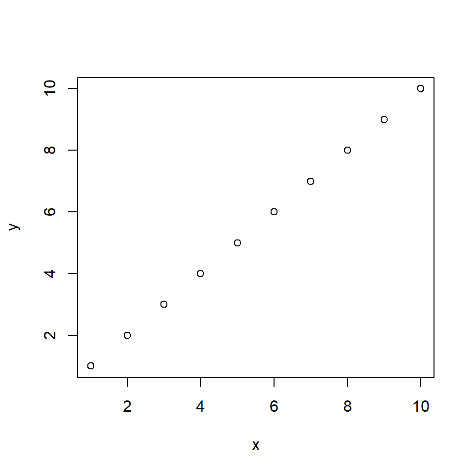

```r
x = c(1:10)
y = c(1:10)
plot(x,y)
```

- You just see a linear line.
- There is no fancy MathStats involved.
- But it helps to show you the main idea.
- …

## More Features and Cheatsheet

[R Markdown Cheatsheet](https://rstudio.com/wp-content/uploads/2015/02/rmarkdown-cheatsheet.pdf)

[R Markdown - The Definitive Guide](https://bookdown.org/yihui/rmarkdown/presentations.html) Chapters 4 & 7

## Lessons learned

- Leave an empty line before using the # and ## heading tags!
- If you just want to **SHOW** the code: {r echo=TRUE, eval=FALSE}
- And most important: Google is your friend! Don’t hesitate…

## Follow me on GitHub :-)

https://github.com/MarcoLandt-Hayen/Programming_Presentation_B1.git